# Statistics: The Science of Decisions Project

## Background Information

In a Stroop task, participants are presented with a list of words, with each word displayed in a color of ink. The participant’s task is to say out loud the color of the ink in which the word is printed. The task has two conditions: a congruent words condition, and an incongruent words condition. In the congruent words condition, the words being displayed are color words whose names match the colors in which they are printed: for example RED, BLUE. In the incongruent words condition, the words displayed are color words whose names do not match the colors in which they are printed: for example PURPLE, ORANGE. In each case, we measure the time it takes to name the ink colors in equally-sized lists. Each participant will go through and record a time from each condition.

### 1. What is our independent variable? What is our dependent variable?

Independent variable: The color/name of color

Dependent variable: Time taken to recognize the correct color

### 2. What is an appropriate set of hypotheses for this task? What kind of statistical test do you expect to perform? Justify your choices.

Null Hypothesis H<sub>0</sub> (μ<sub>incongurent</sub> ≤ μ<sub>congurent</sub>): The difference in color and it's name doest not effect or reduce the time taken to correctly identify it.

Alternate Hypothesis H<sub>A</sub> (μ<sub>incongurent</sub> > μ<sub>congurent</sub>): Difference in color and it's name increases the time to correctly identify it.

The sample size of our poupation is 24 and the population standard deviation is unknown, so the most suitable test is one-tail t test. Our samples are dependent, because the subjects took the test twice in different conditions and time.

### 3. Report some descriptive statistics regarding this dataset. Include at least one measure of central tendency and at least one measure of variability.

```python
import math
import pandas as pd
import numpy as np
%matplotlib inline
```

```python
stroop_df = pd.read_csv('stroopdata.csv')
```

```python
# Stroop Dataset
stroop_df
```

|  | Congruent | Incongruent |
| --- | --- | --- |
| 0 | 12.079 | 19.278 |
| 1 | 16.791 | 18.741 |
| 2 | 9.564 | 21.214 |
| 3 | 8.630 | 15.687 |
| 4 | 14.669 | 22.803 |
| 5 | 12.238 | 20.878 |
| 6 | 14.692 | 24.572 |
| 7 | 8.987 | 17.394 |
| 8 | 9.401 | 20.762 |
| 9 | 14.480 | 26.282 |
| 10 | 22.328 | 24.524 |
| 11 | 15.298 | 18.644 |
| 12 | 15.073 | 17.510 |
| 13 | 16.929 | 20.330 |
| 14 | 18.200 | 35.255 |
| 15 | 12.130 | 22.158 |
| 16 | 18.495 | 25.139 |
| 17 | 10.639 | 20.429 |
| 18 | 11.344 | 17.425 |
| 19 | 12.369 | 34.288 |
| 20 | 12.944 | 23.894 |
| 21 | 14.233 | 17.960 |
| 22 | 19.710 | 22.058 |
| 23 | 16.004 | 21.157 |

```python
stroop_df.describe()
```

|  | Congruent | Incongruent |
| --- | --- | --- |
| count | 24.000000 | 24.000000 |
| mean | 14.051125 | 22.015917 |
| std | 3.559358 | 4.797057 |
| min | 8.630000 | 15.687000 |
| 25% | 11.895250 | 18.716750 |
| 50% | 14.356500 | 21.017500 |
| 75% | 16.200750 | 24.051500 |
| max | 22.328000 | 35.255000 |

### 4. Provide one or two visualizations that show the distribution of the sample data. Write one or two sentences noting what you observe about the plot or plots.

```
array([[<matplotlib.axes._subplots.AxesSubplot object at 0x1a1f874f60>,
      dtype=object)
```

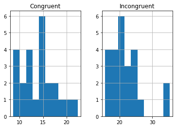

```python
stroop_df.hist()
```

Both the graphs are positively skewed and incongurect data has some outliers

### 5. Now, perform the statistical test and report your results. What is your confidence level and your critical statistic value? Do you reject the null hypothesis or fail to reject it? Come to a conclusion in terms of the experiment task. Did the results match up with your expectations?

Sample size: 24

Diffeence of the means is: 22.015917 - 14.051125 = 7.964792

```python
stroop_df['Difference'] = stroop_df['Incongruent'] - stroop_df['Congruent']
print(stroop_df['Difference'])
stroop_df['Difference'].std(axis=0)
```

```
0      7.199
1      1.950
2     11.650
3      7.057
4      8.134
5      8.640
6      9.880
7      8.407
8     11.361
9     11.802
10     2.196
11     3.346
12     2.437
13     3.401
14    17.055
15    10.028
16     6.644
17     9.790
18     6.081
19    21.919
20    10.950
21     3.727
22     2.348
23     5.153
Name: Difference, dtype: float64
```

```
4.864826910359056
```

Standard deviation of the differences: 4.864826910359056

Degree of freedom (n-1) = 23

For confidence level of 95% and degree of freedom 23, the t-critical value is 1.714

t-statistic value is: 8.023842943437899

```python
7.96/(4.86/math.sqrt(24))
```

```
8.023842943437899
```

t-statistic value 8.023842943437899 is greater then t-critical value 1.714. Based on above values, we reject the null hypothesis.

It means that it take more time to identify incongurrent word.